# Машинное обучение. ВМК МГУ

# Практическое задание 3: Линейные модели: регрессия

## Уровень: **Исследовательский (Research)**

# О формате сдачи

🔷 **При решении ноутбука используйте данный шаблон**

```
✅ Можно добавлять новые ячейки любых типов
❌ Не нужно удалять текстовые ячейки c разметкой частей ноутбука и формулировками заданий
```

🔷 **При оценивании задач учитывается код**

```
✅ Задания, в которых необходим код, обычно помечаются фразами "Your code here"/"Ваш код" и аналогичными
❌ Ответы на вопросы без сопутствующего кода оцениваются в 0 баллов
❌ Наличе работоспособного кода в ноутбуке, если на сказано иного, обязательно
```

🔷 **При оценивании задач учитываются выводы**

```
✅ Задания, в которых необходимы выводы, обычно помечаются фразами Вывод"/"Ответ на вопрос"/"Ваш текст" и аналогичными
✅ Обычно выводы подразумевают под собой текстовый ответ (можно писать markdown, latex).
✅ Сопутствующие изображения, графики, таблички - приветствуются!
❌ При отсутствии выводов задание не засчитается на полный балл
```

Цель данного задания:

- Узнать, что такое переобучение и как с ним бороться в линейных моделях;
- Понять, чем отличаются разные регуляризаторы;
- Научиться решать задачу регрессии линейными моделями.

**Примерное время выполнения (execution time/время выполнения, если нажать run all) всех ячеек ноутбука при правильной реализации: 7 минут **

# Подготовка рабочей среды

Сначала установим нужные нам версии библиотек. Мы гарантируем, что в данных версиях задание будет корректно отрабатывать.

После установки нужных версий, **возможно,** нужно перезагрузить среду (runtime), но скорее всего вам это не понадобится

На скачивание файла и установку понадобится не более 5 минут.

**Важно!**

Устанавливать нужные версии нужно каждый раз, когда создается новый рантайм. Например, если вы 2 часа подряд делаете это задание, то подготовить библиотеки достаточно 1 раз. Но если вы, например, начали в понедельник, затем закрыли/выключили ноутбук, то при продолжении в среду, вам нужно будет запустить рантайм заново и следовательно заново установить библиотеки.

**Важно!** Если вы предпочитаете делать практические задания на своем личном ноутбуке, то проверьте, что вы установили рабочее окружение в соответствии с гайдом.pdf)

```python
# !!! Данный блок будет работать только в Google-Colab !!!
! gdown 10k8Hwn9kpK9SpK4IEj4-EaWQZqgYT5-Q
! pip install -r /content/requirements_2024_25_for_colab_small.txt
```

```
Downloading...
From: https://drive.google.com/uc?id=10k8Hwn9kpK9SpK4IEj4-EaWQZqgYT5-Q
To: /content/requirements_2024_25_for_colab_small.txt
100% 375/375 [00:00<00:00, 1.18MB/s]
```

Проверим версию библиотеки:

```python
import catboost
assert(catboost.__version__ == '1.2.7')
```

Теперь можно приступать к выполнению задания! :)

```python
import numpy as np
import pandas as pd
import matplotlib.pyplot as plt
import seaborn as sns
import warnings
warnings.simplefilter("ignore")
sns.set(style="darkgrid")
%matplotlib inline
```

## Линейная регрессия и регуляризация

Напомним, что линейная регрессия — это модель следующего вида: $$a(x) = \langle w, x \rangle + b$$ где $w \in \mathbb{R}^d$, $b \in \mathbb{R}$. Обучить линейную регрессию — значит найти $w$ и $b$.

В модели линейной регрессии с $l_2$ регуляризацией мы оптимизируем следующий функционал:

$\frac{1}{N} \cdot ∑_{i=1}^M (w_1 \cdot x_{i1} + \dots w_n \cdot x_{in} + b - y_i)^2 + \frac{\alpha}{2} \cdot \left( w_1^2 + \dots + w_n^2 \right) \rightarrow \min_{w_1, \dots, w_n, b}$

В модели линейной регрессии с $l_1$ регуляризацией мы оптимизируем следующий функционал:

$\frac{1}{N} \cdot ∑_{i=1}^M (w_1 \cdot x_{i1} + \dots w_n \cdot x_{in} + b - y_i)^2 + \alpha \cdot \left( |w_1| + \dots + |w_n| \right) \rightarrow \min_{w_1, \dots, w_n, b}$

### **Задание 1 [1 балл]**

Почему при обучении линейных моделей, коэффициент $b$ не регуляризуется? Дайте ответ с опорой на лекции. Возможно вам также поможет картика из базовой части

**Ваши выводы тут:**  
В $a(x) = \langle w, x \rangle + b$ параметр b является константой, так как не зависит от признаков. Следовательно регуляризация параметра b не имеет никакого смысла, так как это никак не влияет на обучаемость модели. Только фактическое изменение параметра $b$ может изменять качество модели, так как от $b$ зависит смещение.

Рассмотрим модель линейной регрессии с $l_2$ регуляризацией. В sklearn эта модель реализована посредством класса Ridge. В нём есть методы fit и predict. Первый принимает на вход обучающую выборку и вектор целевых переменных и обучает модель, второй, будучи вызванным после обучения модели, возвращает предсказание на выборке.

Сгенерируем случайные данные. Пусть $x$ будет обычным числом из равномерного распределения, а $𝑦=0.5 \cdot x + 0.1$ — целевая переменная. При этом наблюдаем мы $\overline{y} = y + \varepsilon,~\varepsilon \sim N(0, 0.01)$. Добавим в данные к переменной $x$ её же умноженную на $3$. То есть, теперь у нас два признака $x_1$ и $x_2 = 3 \cdot x_1$.

Поскольку $y = c \cdot 0.5 \cdot x_1 + \frac{1 - c}{6} \cdot x_2 + 0.1$, где $c$ любое сколь угодно большое вещественное число. То, как мы могли убедиться в базовой части, без регуляризации есть риск выучить очень большие веса.

Посмотрим, как меняется значения весов, в зависимости от значения коэффициента регуляризации.

```python
from sklearn.linear_model import Ridge
```

```python
np.random.seed(1)
X = np.random.uniform(0, 1, 100)
Y = X * 0.5 + 0.1 + np.random.randn(100) * 0.1

X3 = np.hstack((X[:, None], 3 * X[:, None]))
Y3 = X3[:, 0] * 0.5 + 0.1 + np.random.randn(100) * 0.1
```

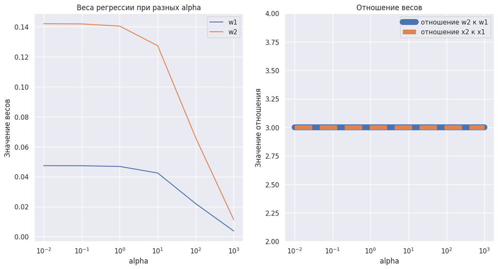

```python
w1 = []
w2 = []

alphas = [0.01, 0.1, 1, 10, 100, 1000]

for alpha in alphas:
    reg = Ridge(alpha=alpha)
    reg.fit(X3, Y3)
    w1.append(reg.coef_[0])
    w2.append(reg.coef_[1])

w1 = np.array(w1)
w2 = np.array(w2)

fig, axs = plt.subplots(figsize=(14, 7), ncols=2)
axs[0].plot(alphas, w1, label="w1")
axs[0].plot(alphas, w2, label="w2")
axs[0].set_xscale("log")
axs[0].set_title("Веса регрессии при разных alpha")
axs[0].set_xlabel("alpha")
axs[0].set_ylabel("Значение весов")
axs[0].legend()
axs[1].plot(alphas, w2 / w1, label="отношение w2 к w1", linewidth=10)
axs[1].plot([0.01, 1000], [3, 3], label="отношение x2 к x1", linestyle="--", linewidth=8)
axs[1].set_xscale("log")
axs[1].set_ylim(2,4)
axs[1].set_xlabel("alpha")
axs[1].set_ylabel("Значение отношения")
axs[1].set_title("Отношение весов")
axs[1].legend()
plt.show()
```

### **Задание 2 [2 баллa]**

Как думаете, почему отношение между весами постоянно? (подсказка, необходимо выписать функцию потерь и посчитать производные по весам)

**Ваши выводы тут:**  
Tак как в нашем примере только 2 признака, то функция потерь:

$L = \frac{1}{2} ∑_{i = 1}^2 (x_{i1}w_1 + x_{i2}w_2 + b - y_i)^2 + \lambda (w_1^2 + w_2^2) $

Найдем частную производную по w1 и w2:

$\frac {\partial L} {\partial w1} = ∑_{i = 1}^2 (x_{i1}w_1 + x_{i2}w_2 + b - y_i)x_{i1} + \lambda 2 w_1 $

$\frac {\partial L} {\partial w2} = ∑_{i = 1}^2 (x_{i1}w_1 + x_{i2}w_2 + b - y_i)x_{i2} + \lambda 2 w_2 $

$\frac {\partial L} {\partial w_j} = 0,$ $j = 1, 2$ так как мы хотим минимизировать функцию потерь

$ ∑_{i = 1}^2 (x_{i1}w_1 + x_{i2}w_2 + b - y_i)x_{ij} + \lambda 2 w_j = 0,$ $j = 1, 2$

$w_j = \frac{∑_{i = 1}^2 (x_{i1}w_1 + x_{i2}w_2 + b - y_i)x_{ij}}{-2 \lambda }, $ $j = 1, 2$

$\frac{w_1}{w_2} = \frac{∑_{i = 1}^2 (x_{i1}w_1 + x_{i2}w_2 + b - y_i){x_{i1}} }{-2 \lambda } \cdot \frac{-2 \lambda }{∑_{i = 1}^2 (x_{i1}w_1 + x_{i2}w_2 + b - y_i)x_{i2}} = \frac{x_{1}} {x_{2}}$

Когда признаки зависят друг от друга, то изменение одного влияет на изменение другого. По формуле веса зависят от признаков, пропорция между признаками не меняется, т.к. $x_2 = 3 * x_1$, значит и отношение весов постоянно.

Заметим, что при $l_2$ регуляризации в данном примере веса получились пропорциональны значениям признаков. При этом, мы знаем, что оба признака взаимно однозначны, и прогноз можно делать только по одному из них. Для этого придумана $l_1$ регуляризация. В билиотеке sklearn линейная регрессия с $l_1$ регуляризацией реализована в классе Lasso

### **Задание 3 [2 баллa]**

Почему в нашем примере $l_1$ регуляризация приведёт к разреживанию весов? (подсказка, нужно опять подсчитать производную, но обратите внимание на дифференцируемость модуля).

**Ваши выводы тут:**  
Tак как в нашем примере только 2 признака, то функция потерь:  
$L = \frac{1}{2} ∑_{i = 1}^2 (x_{i1}w_1 + x_{i2}w_2 + b - y_i)^2 + \lambda (|w_1| + |w_2|)$

посчитаем производную по $w_j$:

$\frac {\partial L} {\partial w_j} = ∑_{i = 1}^2 (x_{i1}w_1 + ... + x_{in}w_n + b - y_i)x_{ij} + \lambda sign(w_j) = 0$, $ j = 1, 2$

в производной появляется $\lambda sign(w_i)$, который направляет веса к 0. Производную L1 можно рассматривать как намеренное удаление константы от веса каждый раз. Это заставляет модель занулять некоторые веса, тем самым исключая соответствующие признаки из модели.

Добавим $l_1$ регуляризацию и посмотрим, как меняется значения весов, в зависимости от значения коэффициента регуляризации.

```python
from sklearn.linear_model import Lasso
```

```python
reg = Lasso(alpha=1., max_iter=1000, tol=1e-4)
reg.fit(X3, Y3)
print("Веса, при alpha = 1.")
print("w1:", reg.coef_[0], "\tw2:", reg.coef_[1])
print()

reg = Lasso(alpha=0.1, max_iter=1000, tol=1e-4)
reg.fit(X3, Y3)
print("Веса, при alpha = 0.1")
print("w1:", reg.coef_[0], "\tw2:", reg.coef_[1])
print()

reg = Lasso(alpha=0.01, max_iter=1000, tol=1e-4)
reg.fit(X3, Y3)
print("Веса, при alpha = 0.01")
print("w1:", reg.coef_[0], "\tw2:", reg.coef_[1])
print()

reg = Lasso(alpha=0.001, max_iter=1000, tol=1e-4)
reg.fit(X3, Y3)
print("Веса, при alpha = 0.001")
print("w1:", reg.coef_[0], "\tw2:", reg.coef_[1])
print()

reg = Lasso(alpha=0.0001, max_iter=1000, tol=1e-4)
reg.fit(X3, Y3)
print("Веса, при alpha = 0.0001")
print("w1:", reg.coef_[0], "\tw2:", reg.coef_[1])
print()

reg = Lasso(alpha=0.00001, max_iter=1000, tol=1e-4)
reg.fit(X3, Y3)
print("Веса, при alpha = 0.00001")
print("w1:", reg.coef_[0], "\tw2:", reg.coef_[1])
print()
```

```
Веса, при alpha = 1.
w1: 0.0 	w2: 0.0

Веса, при alpha = 0.1
w1: 0.0 	w2: 0.029684463509327023

Веса, при alpha = 0.01
w1: 0.0 	w2: 0.14506160917248503

Веса, при alpha = 0.001
w1: 0.0 	w2: 0.1565993237388008

Веса, при alpha = 0.0001
w1: 0.0 	w2: 0.1577530951954324

Веса, при alpha = 0.00001
w1: 0.3966873199145481 	w2: 0.025639365702912847
```

### **Задание 4 [2 баллa]**

Почему в итоге при $\alpha = 0.00001$ получились веса не равные нулю?

**Подсказка**

Обратите внимание на то, каким странным получился вес $w_2$

**Ваши выводы тут:**  
Коэффицент регурялизации отвечает за степень штрафа, накладываемого на велечину коэффицентов модели, следовательно при более низком $a$ у нас будет маленький штраф за сложность. Таким образом при маленьком $a$ коэффиценты меняются не значительно на каждой итерации. И можно предположить, что чтобы обнулить какой либо коэффицент необходимо провести больше итерации.

```python
print("Веса, при alpha = 0.00001")
print("w1:", reg.coef_[0], "\tw2:", reg.coef_[1])
print("Kоличество итераций:", reg.n_iter_ )
```

```
Веса, при alpha = 0.00001
w1: 0.3966873199145481 	w2: 0.025639365702912847
Kоличество итераций: 1000
```

Видно что количество итераций максимально, но этого недостаточно для зануления. Если сделать количество итераций например 7000, то один из коэффициентов занулится.

```python
reg = Lasso(alpha=0.00001, max_iter=7000, tol=1e-4)
reg.fit(X3, Y3)
print("Веса, при alpha = 0.00001")
print("w1:", reg.coef_[0], "\tw2:", reg.coef_[1])
```

```
Веса, при alpha = 0.00001
w1: 0.0 	w2: 0.15786847234109577
```

В предущих блоках мы использовали модельные примеры, в которых $y$ зависел от $x$ линейно. Но так бывает далеко не всегда.

### **Задание 5 [1 баллa]**

Придумайте, сгенерируйте и визуализируйте пример, в котором линейная регрессия будет плохо классифицировать данные.

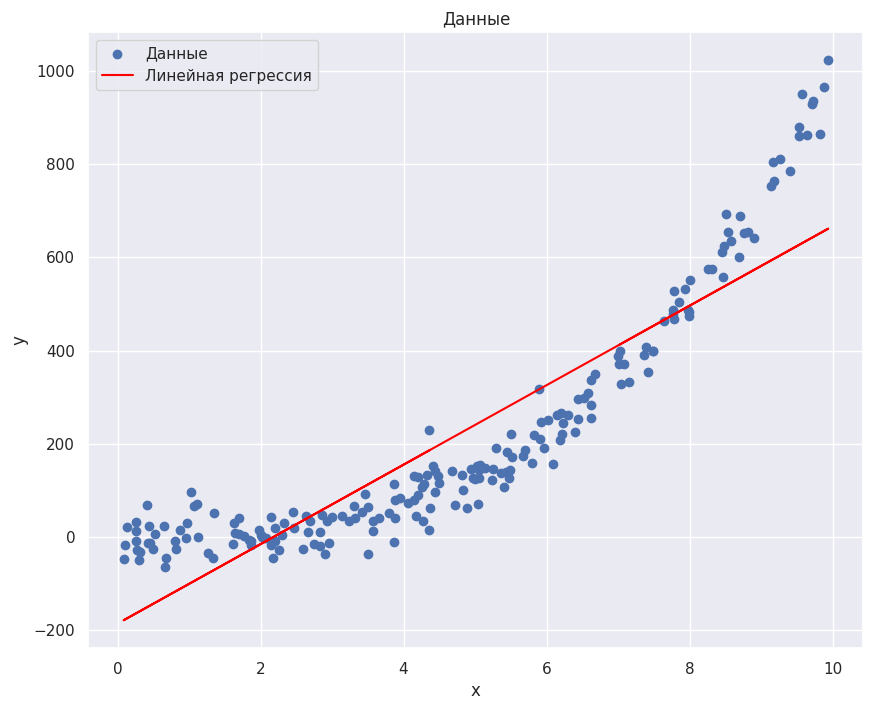

```
MSE loss: 12895.17173155969
```

```python
import matplotlib.pyplot as plt
from sklearn.linear_model import LinearRegression


np.random.seed(2)
X = np.random.uniform(0, 10, 200)
Y = X * X * X + 2 + np.random.randn(200) * 35

plt.figure(figsize=(10,8))
plt.scatter(X, Y, label='Данные')

model = LinearRegression()
X = X.reshape(-1, 1)
model.fit(X, Y)
Y_pred = model.predict(X)


plt.plot(X, Y_pred, color='red', label='Линейная регрессия')
plt.legend()
plt.title("Данные")
plt.xlabel("x")
plt.ylabel("y")
plt.show()

print("MSE loss:", np.mean((Y_pred - Y) ** 2))
```

Очевидно, что линейная регрессия плохо классифицирует данные. В этом можем убедиться, так как большое MSE.

### **Задание 6 [2 баллa]**

Приведите искусственный пример (можно даже очень неправдоподобный), когда линейная регрессия с $l_2$ регуляризацией гарантированно занулит какой-нибудь признак? Покажите (теоретически или программно), что признак действительно зануляется

```python
from sklearn.model_selection import train_test_split
from sklearn.metrics import mean_squared_error

np.random.seed(3)
X = np.ones((150, 5))
X[:, 1] = 2
X[:, 2] = np.random.randint(0, 100, 150)
X[:, 3] = 3
X[:, 4] = np.random.randint(0, 100, 150)

Y = (1 + X[:, 2] + X[:, 3] + X[:, 4]) / 2
X_train, X_test, y_train, y_test = train_test_split(X, Y, test_size=0.3, random_state=42)

model = Ridge(alpha=1.0)
model.fit(X_train, y_train)

coef = model.coef_
print("Веса модели:")
for i in range(len(coef)):
    print(f"w{i+1} = {coef[i]}")

# Оценим качество модели с помощью метрики RMSE
rmse = np.sqrt(mean_squared_error(y_test, model.predict(X_test)))
print(f"RMSE модели: {rmse:.15f}")
```

```
Веса модели:
w1 = 0.0
w2 = 0.0
w3 = 0.49999387047138966
w4 = 0.0
w5 = 0.499994519123152
RMSE модели: 0.000211717326580
```

**Ваши выводы тут:**  
Показал программно, при каких условиях коэффиценты могут зануляться.

**Выводы** В первой части задания по линейным моделям мы должны были узнать: .

1. Зачем нужна регуляризация.
2. Как отбирать значащие признаки.
3. Когда линейные модели работают хорошо, а когда плохо

Во **второй части** мы будем применять линейные модели для классификации реальных данных, где мы сможем проверить наши выводы, полученные на искуственных примерах. А также убедимся в полезности нормировки и научимся работать с разными видами данных.